# Cluster global bird population based on traits

```r
library(tidyverse)
library(densityClust)
library(scales)
library(ggpubr)
```

Pigot et al (2020) [Macroevolutionary convergence connects morphological form to ecological function in birds] ——————————————————————————————-

PC1: (83%) primary axis of body size PC2: (6%) the spectrum from small to large beaks PC3: (4%) species with short tails and pointed beaks (e.g. kiwis) vs those with long tails and stubby beaks PC4: (3%) species with long tails and pointed beaks vs those with short tails and stubby beaks

Found that dimensionality varied from the two-dimensional niche of nectarivores to the four-dimensional niche of frugivores, and that niches are on average defined by at least three trait dimensions. Taking all trophic niches together, an integrated niche space is minimally described by a four-dimensional morphospace

## Used Query:

SELECT scientific_name, common_name, taxonomic_order, taxonomic_family, body_morphspace.pc1, body_morphspace.pc2, body_morphspace.pc3, body_morphspace.pc4, trophic_niche, foraging_niche FROM `endless-matter-297214.model.taxonomy` WHERE scientific_name in (SELECT scientific_name FROM `endless-matter-297214.model.regional_species_filtered`)

```r
taxonomy <- read_csv("taxonomy.csv")
taxonomy
```

| scientific_name | common_name | taxonomic_order | taxonomic_family | pc1 | pc2 | pc3 | pc4 | trophic_niche | foraging_niche |
| --- | --- | --- | --- | --- | --- | --- | --- | --- | --- |
| Artamus cyanopterus | Dusky Woodswallow | Passeriformes | Artamidae (Woodswallows, Bellmagpies, and Allies) | -0.421936775 | 0.035488788 | -0.2620666903 | 0.0181141492 | Invertivore | Invertivore aerial |
| Conopophaga castaneiceps | Chestnut-crowned Gnateater | Passeriformes | Conopophagidae (Gnateaters) | -0.773261871 | 0.025184258 | 0.2131983899 | 0.2651388649 | Invertivore | Invertivore sally ground |
| Lanius meridionalis | Iberian Gray Shrike | Passeriformes | Laniidae (Shrikes) | 0.446204020 | -0.005413290 | -0.3676188017 | -0.0345559727 | Invertivore | Invertivore sally ground |
| Pachycephala pectoralis | Golden Whistler | Passeriformes | Pachycephalidae (Whistlers and Allies) | -0.551640756 | 0.063596625 | -0.1613031651 | 0.0114064585 | Invertivore | Invertivore glean arboreal |
| Platalea ajaja | Roseate Spoonbill | Pelecaniformes | Threskiornithidae (Ibises and Spoonbills) | 5.101106174 | -1.232079057 | 0.9196118249 | -0.0769761263 | Aquatic predator | Aquatic ground |
| Psophia crepitans | Gray-winged Trumpeter | Gruiformes | Psophiidae (Trumpeters) | 3.777311912 | 0.982909711 | 0.4333303905 | -0.0807387083 | Frugivore | Fugivore ground |
| Smithornis capensis | African Broadbill | Passeriformes | Calyptomenidae (African and Green Broadbills) | -0.908013951 | -0.310217277 | -0.3401429255 | 0.6667576128 | Invertivore | Invertivore sally surface |
| Trachyphonus erythrocephalus | Red-and-yellow Barbet | Piciformes | Lybiidae (African Barbets) | 0.603771597 | -0.430507842 | -0.2093668474 | 0.0739191545 | Omnivore | NA |
| Vidua wilsoni | Wilson's Indigobird | Passeriformes | Viduidae (Indigobirds) | -1.904606929 | 0.149416592 | -0.2520598657 | 0.6149220492 | Granivore | Granivore ground |
| Bucco tamatia | Spotted Puffbird | Galbuliformes | Bucconidae (Puffbirds) | -0.011323091 | -1.065022978 | -0.2069365216 | 0.4543759152 | Invertivore | Invertivore sally surface |

[output cut: 990 more lines]

```
Clustering k = 1,2,..., K.max (= 10): .. done
Bootstrapping, b = 1,2,..., B (= 100)  [one "." per sample]:
..
```

```
......
```

```
.......................................... 50
..........................
```

```
........................ 100
```

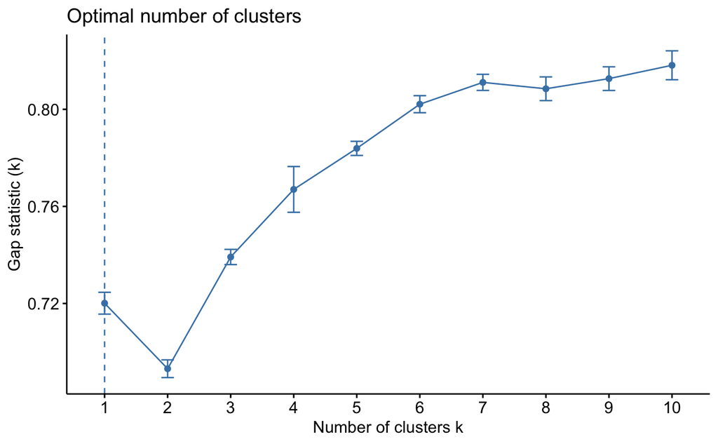

```r
library(factoextra)
fviz_nbclust(taxonomy[,c("pc1", "pc2", "pc3", "pc4")], kmeans, method = "gap_stat")
```

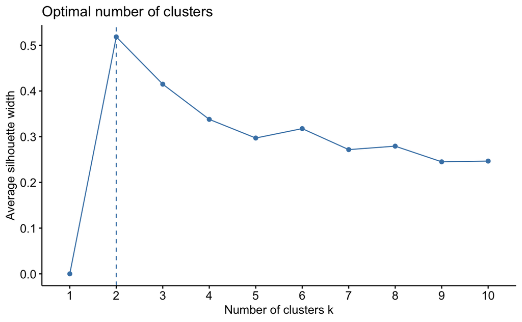

```r
fviz_nbclust(taxonomy[,c("pc1", "pc2", "pc3", "pc4")], kmeans, method = "silhouette")
```

Mouillot et al (2021) [The dimensionality and structure of species trait spaces] ———————————————————- Measure of trait space quality:

1. being unitless so independent of the number, range or value of traits;
2. being standardised between 0 and 1 with a clear and intuitive interpretation of these extreme values;
3. avoiding the dilemma of whether or not to square the error, which arises in distance- based quality metrics;
4. being asymmetric by construction so only considering that the lower dimensional distance matrix is a poorer representation of species distribution in trait space compared with the initial distance matrix;
5. proposing a common, albeit arbitrary, threshold to define quality.

To cluster species in the trait space and potentially identify unique species, we used the ‘clustering by fast search and find of density peaks’ algorithm, which is based on initial pairwise distances and does not require dimensionality reduction (Rodriguez & Laio, 2014)

```r
sqrt2 <- function(x) {
  (x / abs(x)) * sqrt(abs(x))
}
```

```r
sqrt2(2)
```

```
[1] 1.414214
```

```r
sqrt2(0)
```

```
[1] NaN
```

```r
sqrt2(-2)
```

```
[1] -1.414214
```

```r
taxonomy$pc1_sqrt <- sqrt2(taxonomy$pc1)
taxonomy$pc2_sqrt <- sqrt2(taxonomy$pc2)
taxonomy$pc3_sqrt <- sqrt2(taxonomy$pc3)
taxonomy$pc4_sqrt <- sqrt2(taxonomy$pc4)
```

```r
set.seed(123123123)
```

```r
distribution <- dist(taxonomy[,c("pc1", "pc2", "pc3", "pc4")])
clustered <- densityClust(distribution, gaussian=TRUE)
```

```
Distance cutoff calculated to 0.3777909
```

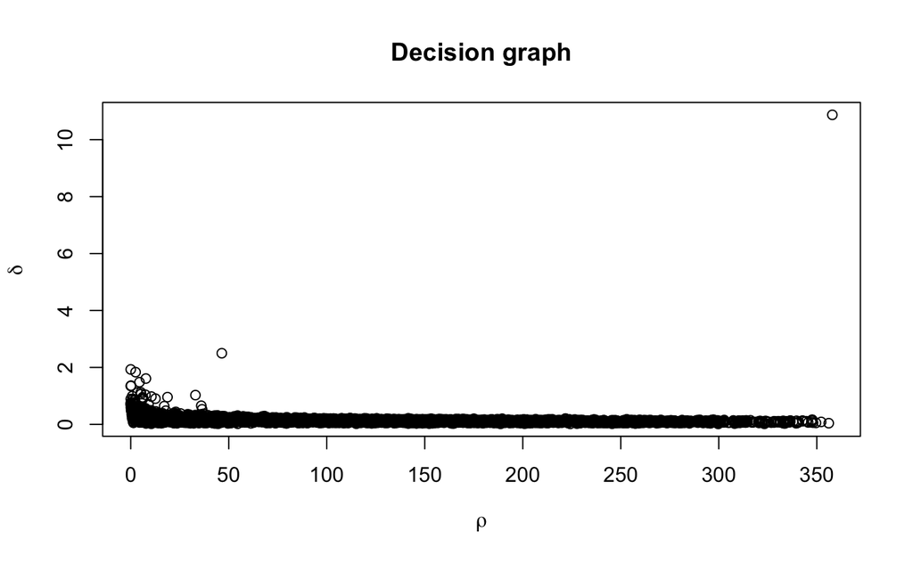

```r
plot(clustered)
```

RHO - The threshold for local density when detecting cluster peaks Delta - The threshold for minimum distance to higher density when detecting cluster peaks

```r
clusters <- findClusters(clustered, rho=0.2, delta=0.5)
clusters
```

```
A densityCluster object with 86 clusters defined

Number of observations: 6444
Observations in core:   1356

Parameters:
dc (distance cutoff)   rho threshold          delta threshold
0.3778                 0.2                    0.5
```

```r
clusters_half <- findClusters(clustered, rho=0.2, delta=0.6)
clusters_half
```

```
A densityCluster object with 38 clusters defined

Number of observations: 6444
Observations in core:   1477

Parameters:
dc (distance cutoff)   rho threshold          delta threshold
0.3778                 0.2                    0.6
```

```r
clusters_double <- findClusters(clustered, rho=0.2, delta=0.4)
clusters_double
```

```
A densityCluster object with 204 clusters defined

Number of observations: 6444
Observations in core:   1505

Parameters:
dc (distance cutoff)   rho threshold          delta threshold
0.3778                 0.2                    0.4
```

```r
taxonomy$cluster <- clusters$clusters
taxonomy$cluster_half <- clusters_half$clusters
taxonomy$cluster_double <- clusters_double$clusters
```

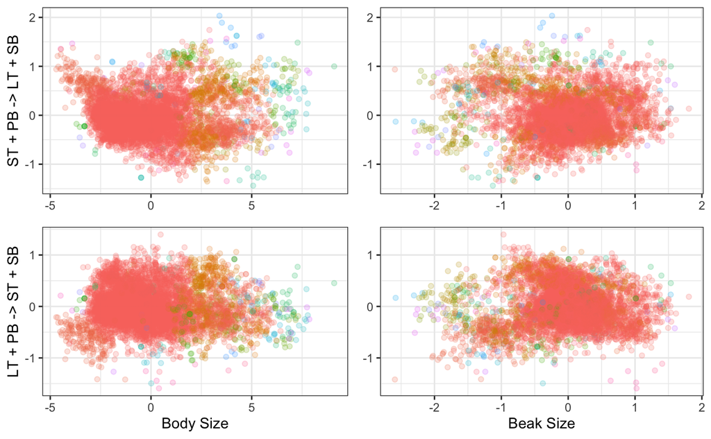

```r
ggarrange(
  ncol = 2,
  nrow = 2,
  ggplot(taxonomy, aes(x = pc1, y = pc3, colour = as.factor(cluster))) + geom_point(alpha = 0.2) + theme_bw() +  theme(legend.position="none", axis.title.x=element_blank()) + ylab("ST + PB -> LT + SB"),
  ggplot(taxonomy, aes(x = pc2, y = pc3, colour = as.factor(cluster))) + geom_point(alpha = 0.2) + theme_bw() + theme(legend.position="none", axis.title.x=element_blank(), axis.title.y=element_blank()),
  ggplot(taxonomy, aes(x = pc1, y = pc4, colour = as.factor(cluster))) + geom_point(alpha = 0.2) + theme_bw() + theme(legend.position="none") + ylab("LT + PB -> ST + SB") + xlab("Body Size"),
  ggplot(taxonomy, aes(x = pc2, y = pc4, colour = as.factor(cluster))) + geom_point(alpha = 0.2) + theme_bw() + theme(legend.position="none", axis.title.y=element_blank()) + xlab("Beak Size")
)
```

```r
results <- taxonomy[order(taxonomy$cluster, taxonomy$trophic_niche, taxonomy$foraging_niche),c("cluster", "cluster_half", "cluster_double", "foraging_niche", "trophic_niche", "common_name", "taxonomic_order", "scientific_name")]
results
```

| cluster | cluster_half | cluster_double | foraging_niche | trophic_niche | common_name | taxonomic_order | scientific_name |
| --- | --- | --- | --- | --- | --- | --- | --- |
| 1 | 1 | 1 | Aquatic aerial | Aquatic predator | White-winged Tern | Charadriiformes | Chlidonias leucopterus |
| 1 | 1 | 1 | Aquatic aerial | Aquatic predator | Black Tern | Charadriiformes | Chlidonias niger |
| 1 | 1 | 167 | Aquatic aerial | Aquatic predator | Black Skimmer | Charadriiformes | Rynchops niger |
| 1 | 1 | 135 | Aquatic aerial | Aquatic predator | Indian Skimmer | Charadriiformes | Rynchops albicollis |
| 1 | 1 | 135 | Aquatic aerial | Aquatic predator | African Skimmer | Charadriiformes | Rynchops flavirostris |
| 1 | 1 | 1 | Aquatic aerial | Aquatic predator | Ross's Gull | Charadriiformes | Rhodostethia rosea |
| 1 | 1 | 1 | Aquatic aerial | Aquatic predator | Whiskered Tern | Charadriiformes | Chlidonias hybrida |
| 1 | 1 | 127 | Aquatic dive | Aquatic predator | Eared Grebe | Podicipediformes | Podiceps nigricollis |
| 1 | 1 | 1 | Aquatic dive | Aquatic predator | Long-tailed Cormorant | Suliformes | Microcarbo africanus |
| 1 | 1 | 1 | Aquatic dive | Aquatic predator | Little Cormorant | Suliformes | Microcarbo niger |

[output cut: 990 more lines]

```r
write_csv(taxonomy[,c("scientific_name", "cluster", "cluster_half", "cluster_double")], "result.csv")
```